# MLR Analysis

Hector Mathonsi

14 October 2024

# MLR: Sales Analysis

The annual data on advertising, promotions, sales expenses and sales for a sample of companies is given in the sales.csv dataset. All variables are measured in millions of dollars. Fit a MLR model to predict sales using the other three variables.

## Load the Data

```r
sales <- read.csv("../data/sales.csv", header = TRUE)
sales
```

| sales | advertising | promotion | expenses |
| --- | --- | --- | --- |
| 20.1 | 2.0 | 1.0 | 0.30 |
| 15.1 | 1.9 | 0.0 | 0.30 |
| 18.7 | 2.2 | 0.8 | 0.35 |
| 16.0 | 2.0 | 0.0 | 0.35 |
| 21.3 | 1.7 | 1.3 | 0.30 |
| 17.9 | 1.7 | 0.3 | 0.32 |
| 18.9 | 2.1 | 1.0 | 0.31 |
| 21.3 | 1.0 | 1.0 | 0.41 |
| 20.5 | 2.0 | 0.9 | 0.45 |
| 20.5 | 1.1 | 1.0 | 0.45 |

[output cut: 12 more lines]

## Fit the MLR Model

```r
sales_model <- lm(sales ~ advertising + promotion + expenses, data = sales)
summary(sales_model)
```

```
Call:
lm(formula = sales ~ advertising + promotion + expenses, data = sales)

Residuals:
     Min       1Q   Median       3Q      Max
-2.08963 -0.85274  0.04115  0.57856  2.57964

Coefficients:
            Estimate Std. Error t value Pr(>|t|)
(Intercept)   5.9141     1.8445   3.206  0.00489 **
advertising   1.1127     0.6954   1.600  0.12701
promotion     4.5865     0.6455   7.106 1.27e-06 ***
expenses     22.5791     2.0326  11.108 1.73e-09 ***
---
Signif. codes:  0 '***' 0.001 '**' 0.01 '*' 0.05 '.' 0.1 ' ' 1

Residual standard error: 1.292 on 18 degrees of freedom
Multiple R-squared:  0.9104,    Adjusted R-squared:  0.8954
F-statistic: 60.93 on 3 and 18 DF,  p-value: 1.264e-09
```

Based on the F-statistic, the model is highly significant. Based on the RSE we can say that the model accurately predicts sales with about 1.292 error, on average. Based on the R2, approximately 91% of the variation in sales is explained by the variation in the three independent variables in the model. All this indicates a good model fit.

## Check Multicollinearity

```r
# Check for multicollinearity
cor(sales)
```

```
                 sales advertising   promotion    expenses
sales        1.0000000  -0.1402891  0.54185188  0.80956373
advertising -0.1402891   1.0000000 -0.34021309 -0.10058307
promotion    0.5418519  -0.3402131  1.00000000  0.06258872
expenses     0.8095637  -0.1005831  0.06258872  1.00000000
```

## Residual Analysis

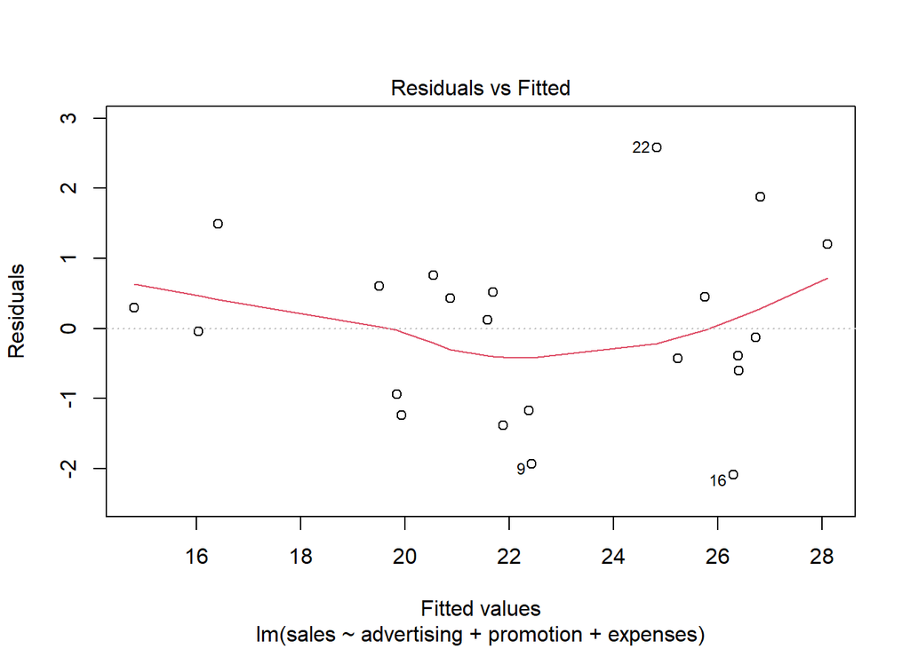

```r
# Residual plot (residual vs. predicted)
plot(sales_model, which = 1)    # Residuals vs Fitted: Check for linearity
```

There appears to be a pattern in the residuals, indicating possible non-linearity in the data. this may also be due to the presence of outliers.

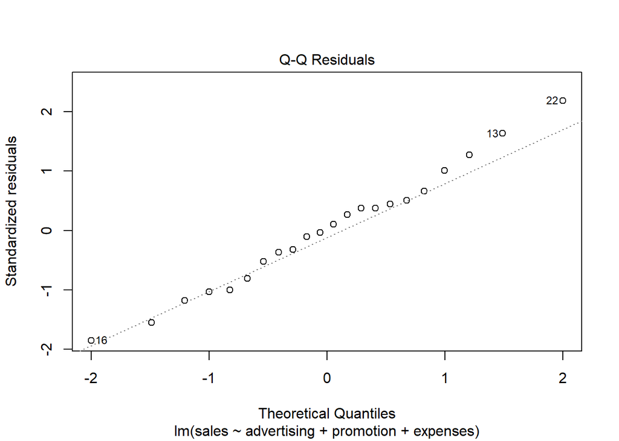

```r
# Normal Q-Q plot
plot(sales_model, which = 2)    # Normal Q-Q: Check for normality
```

The Q-Q plot appears to show approximately normality.

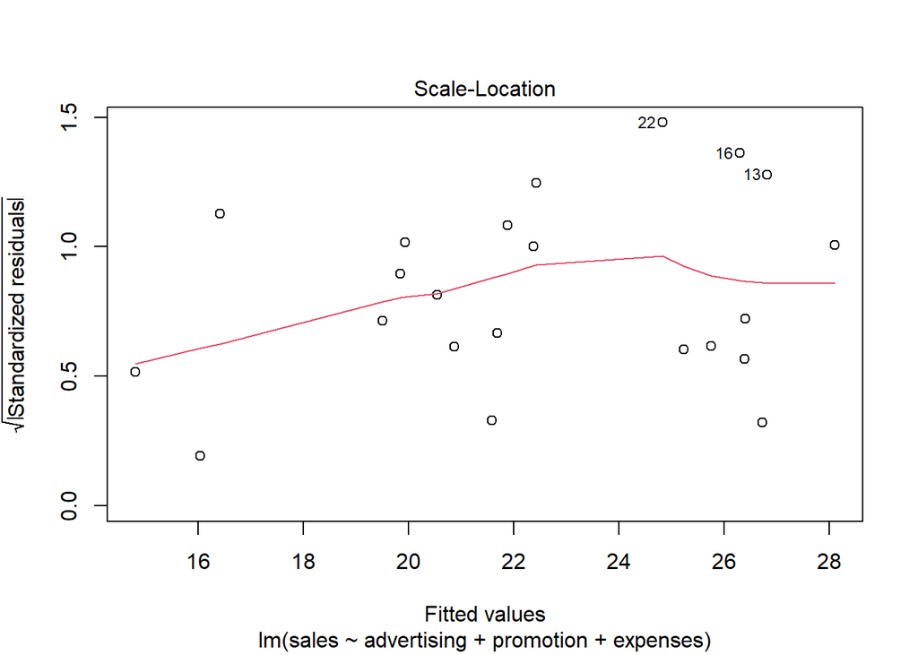

```r
# Scale-Location plot
plot(sales_model, which = 3)    # Scale-Location; Check for homoscedasticity
```

The graph shows that residuals appear somewhat randomly scattered, but it is still affected by the potential outliers.

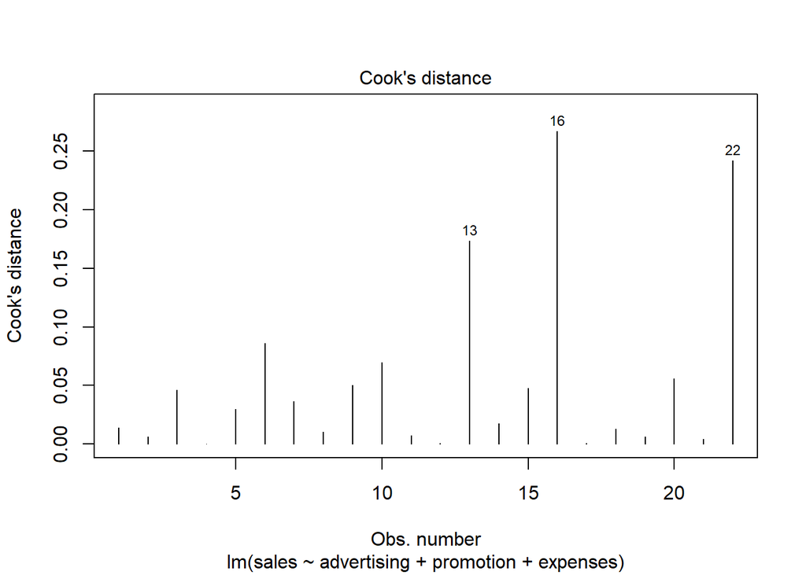

```r
# Residuals vs Leverage plot
plot(sales_model, which = 4)    # Residuals vs Leverage: Check for influential points
```

The plot shows that observation 13, 16 and 22 are outliers. We could remove outliers, remove insignificant variables, or transform variables to try to improve the model. However, this is a very small dataset (n = 22) and we do not see much improvement when we do any of the above. For regression analysis, we use a rule of thumb of 10 observations for each independent variable. More data is better.